# Analyzing the crimes committed in San Francisco from June 2003 to May 2015

Rohan Thakkar

October 24, 2015

As my attempt to predict the category of crimes that occurred in the city by the bay, the dataset retrieved from https://www.kaggle.com/c/sf-crime is a collection of all crimes committed in San Francisco during the period of 6 June, 2003 to 13 May, 2015.

Since the number of rows is pretty huge (878049!!!), I will display the names of columns of the dataset -

```
##       [,1]
##  [1,] "Dates"
##  [2,] "Category"
##  [3,] "Descript"
##  [4,] "DayOfWeek"
##  [5,] "PdDistrict"
##  [6,] "Resolution"
##  [7,] "Address"
##  [8,] "X"
##  [9,] "Y"
```

Other than the five self-explanatory columns,

- “PdDistrict” represents the district of the police department that was responsible of curbing the crime.
- “Resolution” represents the outcome of investigation on crime.
- “X” represents the X co-ordinate of the location where the crime took place.
- “Y” represents the Y co-ordinate of the location where the crime took place.

**Analysis 1 - Calculating the number of crimes for each district to determine the one with maximum occurences of crime.**

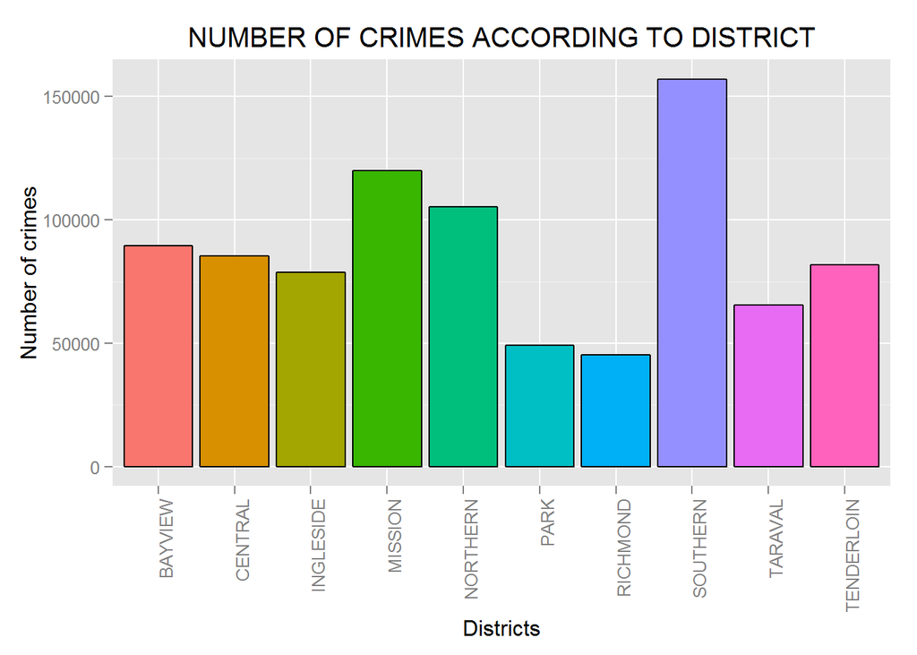

*As we can see from the above graph, the “Southern” district has recorded the highest number of crimes and can, thus, be predicted to be at the highest danger. Thus, I won’t be surprised if the rates of real estate start falling in that area after people recognize this trend.*

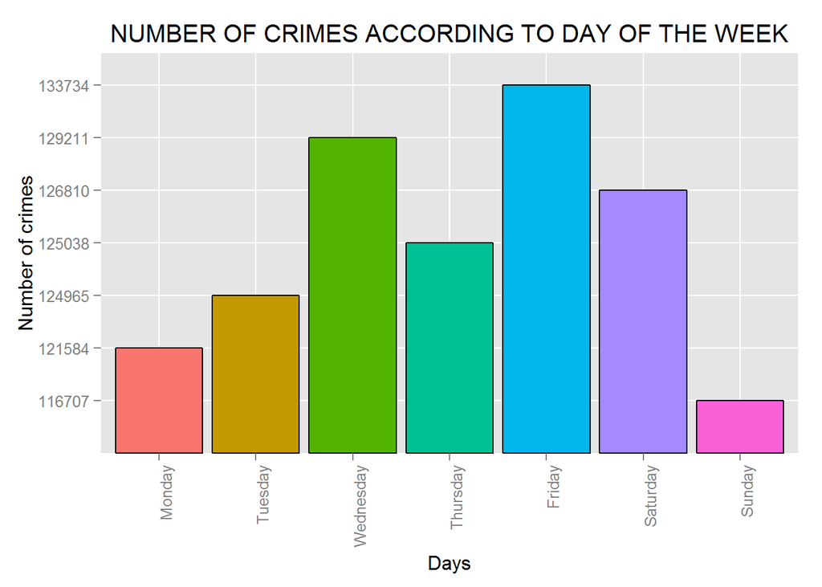

*Friday has, thus, observed higher crimes than any other day in the history and is, thus, considered as the least safe day to hang around at San Francisco.*

**Analysis 3 - To find out the outcome of the investigation of the convicted for each crime**

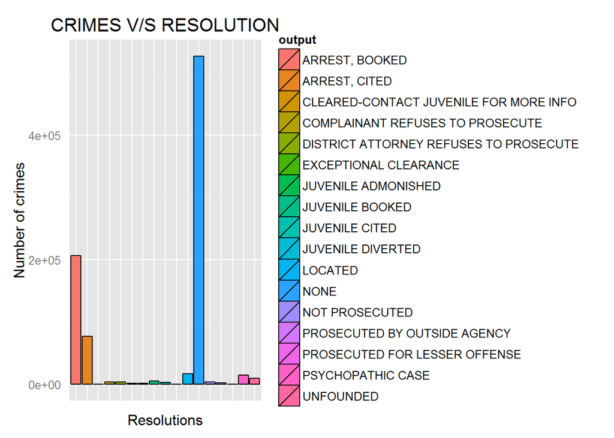

*As we can see above, most criminals fall under the ‘none’ category, which means that major of the crimes committed in SF do not fall under any of the defined categories of resolution, which is also evidenced by the minute length of several of the bars in the graph*

So let us ignore that resolution and see only the well-defined ones

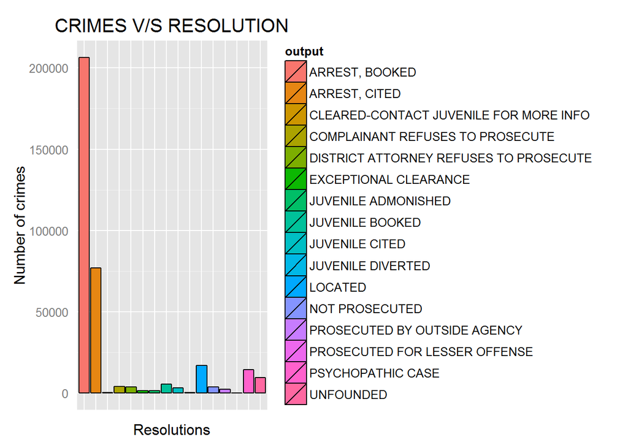

*So after overloooking that category, the next highest category is ‘Arrested - Booked’ followed by ‘Arrested - Cited’ which have a much larger number of crimes under them, when compared to the case of ‘unfounded’ crimes, that certifies the capability of the SFPD*

**Analysis 4 - Calculating the number of each type of crime committed**

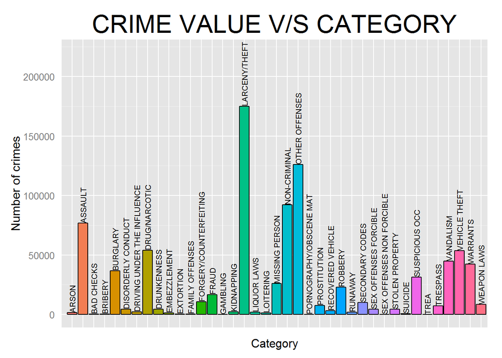

*The most common type of crime committed is ‘Larceny/Theft’, followed by ‘other offenses’*

**Visualization 1 - Display the locations of occurences of crimes for each district on weekdays? (Monday - Friday)**

[figure not shown]

**Visualization 2 - Display the locations of occurences of crimes for each district on weekends (Saturday & Sunday)**

[figure not shown]

In case you need to contact me, please feel free to shoot me an email at rohan27@uw.edu

*Thank you for viewing!*